# Neighborhood in MAC

September, 15th 2017

We want to characterize how is the neighborhood of each species. More precisely, we want to define

1. How many trees of each species are in the neighborhood of a certain target species
2. How the functional diversity varies among target species

### (1) Specific neighborhood

We could first calculate how many neighbours has a tree of a certain species on average, and compare the results across species

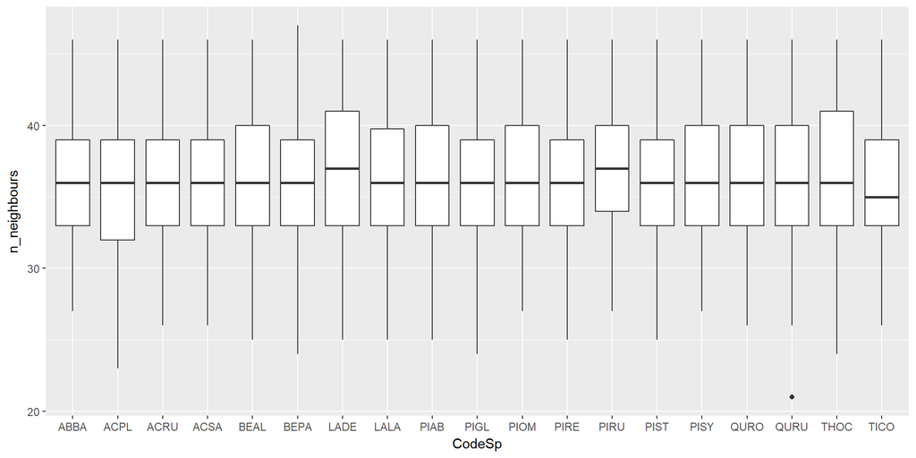

```r
ggplot(targets) +
        geom_boxplot( aes (CodeSp, n_neighbours))
```

We can see there are no big differences, as expected. We can now check how many neighbours of each species has a given target species

```r
neighbour_sps <- table (neighbours$CodeSp_IN, neighbours$CodeSp_NEAR)
kable(addmargins(neighbour_sps,1), format ="html") %>%
        kable_styling(bootstrap_options =  c("striped","hover", "condensed", "responsive"), full_width = F, font_size = 12,
                      position = "left") %>%
        column_spec(1, bold = T, border_right = T)
```

|  | ABBA | ACPL | ACRU | ACSA | BEAL | BEPA | LADE | LALA | PIAB | PIGL | PIOM | PIRE | PIRU | PIST | PISY | QURO | QURU | THOC | TICO |
| --- | --- | --- | --- | --- | --- | --- | --- | --- | --- | --- | --- | --- | --- | --- | --- | --- | --- | --- | --- |
| ABBA | 11792 | 293 | 2390 | 2541 | 312 | 742 | 141 | 776 | 76 | 1560 | 337 | 966 | 1299 | 351 | 99 | 222 | 334 | 270 | 225 |
| ACPL | 296 | 8094 | 722 | 646 | 629 | 1068 | 81 | 167 | 562 | 207 | 545 | 175 | 202 | 205 | 315 | 240 | 198 | 511 | 604 |
| ACRU | 2327 | 738 | 13734 | 528 | 3236 | 834 | 74 | 519 | 225 | 388 | 120 | 490 | 635 | 1008 | 352 | 186 | 1238 | 2588 | 678 |
| ACSA | 2468 | 634 | 513 | 13996 | 794 | 1207 | 109 | 2160 | 166 | 1851 | 778 | 417 | 750 | 1019 | 233 | 201 | 285 | 2662 | 359 |
| BEAL | 297 | 632 | 3121 | 795 | 12105 | 773 | 30 | 464 | 405 | 844 | 262 | 713 | 956 | 937 | 272 | 224 | 2136 | 891 | 614 |
| BEPA | 740 | 1104 | 833 | 1247 | 807 | 13955 | 210 | 1104 | 657 | 1540 | 598 | 560 | 1155 | 2937 | 649 | 761 | 2684 | 825 | 174 |
| LADE | 104 | 68 | 60 | 102 | 25 | 185 | 6213 | 116 | 132 | 149 | 44 | 632 | 132 | 307 | 485 | 190 | 428 | 96 | 59 |
| LALA | 789 | 170 | 519 | 2213 | 478 | 1101 | 150 | 14387 | 654 | 2868 | 321 | 198 | 808 | 2797 | 656 | 194 | 941 | 1050 | 267 |
| PIAB | 77 | 589 | 249 | 173 | 411 | 655 | 156 | 661 | 8642 | 642 | 119 | 275 | 685 | 449 | 1192 | 207 | 202 | 1175 | 148 |
| PIGL | 1578 | 201 | 374 | 1918 | 863 | 1524 | 179 | 2863 | 643 | 14381 | 191 | 1288 | 1616 | 3813 | 933 | 522 | 509 | 1371 | 813 |
| PIOM | 260 | 352 | 79 | 481 | 177 | 393 | 42 | 255 | 73 | 135 | 5389 | 165 | 52 | 301 | 78 | 43 | 173 | 90 | 112 |
| PIRE | 928 | 165 | 481 | 421 | 656 | 518 | 594 | 189 | 242 | 1242 | 237 | 13037 | 3544 | 3023 | 441 | 142 | 665 | 420 | 166 |
| PIRU | 1245 | 199 | 611 | 724 | 900 | 1086 | 148 | 735 | 648 | 1561 | 102 | 3553 | 11463 | 1188 | 1048 | 699 | 377 | 277 | 118 |
| PIST | 357 | 201 | 993 | 1105 | 964 | 2894 | 333 | 2757 | 443 | 3835 | 361 | 3162 | 1295 | 17666 | 300 | 719 | 1481 | 1468 | 866 |
| PISY | 88 | 309 | 351 | 245 | 272 | 584 | 516 | 591 | 1119 | 937 | 120 | 535 | 1005 | 300 | 8929 | 563 | 540 | 915 | 201 |
| QURO | 269 | 218 | 189 | 167 | 151 | 738 | 203 | 169 | 191 | 561 | 74 | 145 | 758 | 724 | 619 | 6917 | 112 | 92 | 503 |
| QURU | 329 | 191 | 1243 | 282 | 2356 | 2664 | 481 | 934 | 200 | 490 | 239 | 815 | 453 | 1501 | 565 | 112 | 11265 | 1462 | 140 |
| THOC | 273 | 516 | 2494 | 2979 | 939 | 801 | 109 | 1057 | 1122 | 1396 | 102 | 438 | 298 | 1488 | 919 | 107 | 1457 | 13009 | 261 |
| TICO | 160 | 593 | 597 | 219 | 605 | 148 | 64 | 238 | 131 | 715 | 156 | 148 | 114 | 774 | 175 | 449 | 118 | 188 | 6306 |
| Sum | 24377 | 15267 | 29553 | 30782 | 26680 | 31870 | 9833 | 30142 | 16331 | 35302 | 10095 | 27712 | 27220 | 40788 | 18260 | 12698 | 25143 | 29360 | 12614 |

In this case, we see that some species are indeed very rare. Since our most complex model has 30 parameters, and some studies recommend that the ratio observations/parameters should be > 10, I decided to collapse all neighbouring species with less than 300 observations into a “other” group.

### (2) Diversity neighborhood

It is time now to assess if the functional diversity neighborhood is very different across target species. Remember we defined species richness using Shannon and two FD indicators: functional difference and functional dispersion. Let’s see each of them

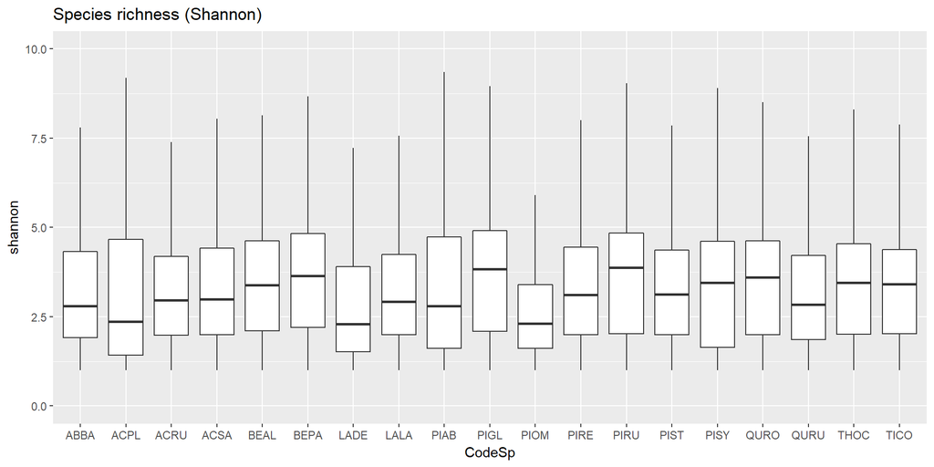

```r
ggplot(targets) +
        geom_boxplot( aes (CodeSp, shannon),outlier.color = NA) +
        ylim(c(0,10)) +
        ggtitle ("Species richness (Shannon)")
```

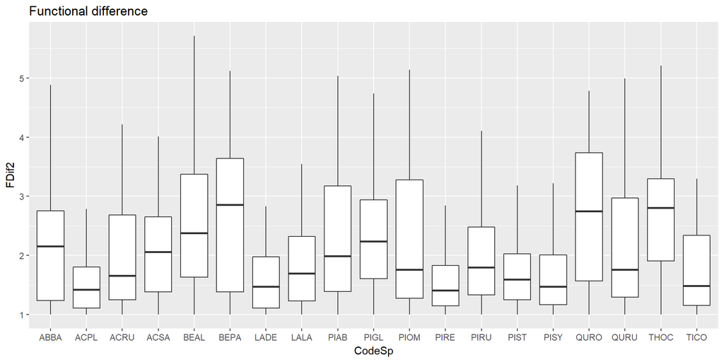

```r
ggplot(targets) +
        geom_boxplot( aes (CodeSp, FDif2), outlier.color = NA) +
        ggtitle ("Functional difference")
```

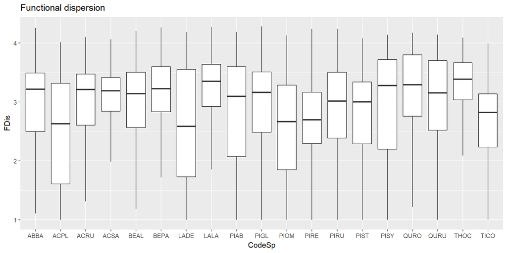

```r
ggplot(targets) +
        geom_boxplot( aes (CodeSp, FDis), outlier.colour = NA) +
        ggtitle ("Functional dispersion")
```

In general, I believe that, despite differences across species, values are similar enough as to don’t correct FD values.